# Supplementary Materials: School Socioeconomic Status Context and Social Skills in Children

# Strengths and Difficulties Questionnare Items

All items ask teachers or parents to consider whether this child’s behaviour over the past 6 months is true or not true of the following statements:

| Prosociality | Conduct Problems | Peer Problems |
| --- | --- | --- |
| Considerate of other people’s feelings | Often has temper tantrums or hot tempers | Rather solitary, tends to play alone |
| Shares readily with other children (treats, toys, pencils, etc) | Generally obedient, usually does what adults request | Has at least one good friend |
| Helpful if someone is hurt, upset or feeling ill | Often fights with other children or bullies them | Generally liked by other children |
| Kind to younger children | Often argumentative with adults | Picked on or bullied by other children |
| Often volunteers to help others (parents, teachers, other children) | Can be spiteful to others | Gets on better with adults than with other children |

# Descriptives

**Characteristic**

**N = 9,369**

**Histogram**

Prior Social (Parent)

[figure not shown]

Median (IQR)

8.00 (6.00, 9.00)

Range

0.00, 10.00

Prior Peer (Parent)

[figure not shown]

Median (IQR)

1.00 (0.00, 2.00)

Range

0.00, 10.00

Prior Conduct (Parent)

[figure not shown]

Median (IQR)

2.00 (1.00, 3.00)

Range

0.00, 10.00

Prior Social (Teacher)

[figure not shown]

Median (IQR)

7.00 (5.00, 9.00)

Range

0.00, 10.00

Prior Peer (Teacher)

[figure not shown]

Median (IQR)

1.00 (0.00, 2.00)

Range

0.00, 10.00

Prior Conduct (Teacher)

[figure not shown]

Median (IQR)

0.00 (0.00, 1.00)

Range

0.00, 10.00

Parent Reported Social

[figure not shown]

Median (IQR)

9.00 (7.00, 10.00)

Range

0.00, 10.00

Parent Reported Peer

[figure not shown]

Median (IQR)

1.00 (0.00, 2.00)

Range

0.00, 10.00

Parent Reported Conduct

[figure not shown]

Median (IQR)

1.00 (0.00, 2.00)

Range

0.00, 10.00

Teacher Reported Social

[figure not shown]

Median (IQR)

8.00 (6.00, 10.00)

Range

0.00, 10.00

Teacher Reported Peer

[figure not shown]

Median (IQR)

1.00 (0.00, 2.00)

Range

0.00, 10.00

Teacher Reported Conduct

[figure not shown]

Median (IQR)

0.00 (0.00, 1.00)

Range

0.00, 10.00

SES

[figure not shown]

Median (IQR)

-0.08 (-0.64, 0.73)

Range

-3.57, 3.00

School SES

[figure not shown]

Median (IQR)

-0.08 (-0.67, 0.70)

Range

-5.64, 2.74

Cohort

B

4,386 (47%)

K

4,983 (53%)

Gender

boy

4,787 (51%)

girl

4,582 (49%)

Place

rural

3,281 (35%)

urban

6,074 (65%)

Verbal Ability (Age 4)

[figure not shown]

Median (IQR)

0.05 (-0.62, 0.70)

Range

-3.43, 3.22

School Sector

Government

5,443 (67%)

Non-Government

2,735 (33%)

## Social Adjustment Categorization for the Sample

| Time Wave | Social Adjustment | Source | Sample Percentage Potential Concern |
| --- | --- | --- | --- |
| Age 8 | Conduct Problems | Parent Report | 7.03% |
| Age 8 | Conduct Problems | Teacher Report | 5.58% |
| Prior | Conduct Problems | Parent Report | 23.30% |
| Prior | Conduct Problems | Teacher Report | 7.06% |
| Age 8 | Peer Problems | Parent Report | 9.71% |
| Age 8 | Peer Problems | Teacher Report | 8.88% |
| Prior | Peer Problems | Parent Report | 10.46% |
| Prior | Peer Problems | Teacher Report | 9.03% |
| Age 8 | Prosociality | Parent Report | 12.90% |
| Age 8 | Prosociality | Teacher Report | 22.03% |
| Prior | Prosociality | Parent Report | 23.49% |
| Prior | Prosociality | Teacher Report | 28.19% |

## Against Australian Norms

Norms taken from the [SDQ website](https://www.sdqinfo.org/norms/AusNorm2.pdf). We used norms separated by gender. Norms are for children aged 7-10 years old.

| Social Adjustment | Source | Boy Sample Mean | Girl Sample Mean | Boy Norm Mean | Girl Norm Mean |
| --- | --- | --- | --- | --- | --- |
| Conduct Problems | Parent Report | 1.5 | 1.1 | 1.8 | 1.3 |
| Peer Problems | Parent Report | 1.6 | 1.3 | 1.8 | 1.5 |
| Prosociality | Parent Report | 8.0 | 8.7 | 8.0 | 8.7 |
| Conduct Problems | Teacher Report | 1.1 | 0.5 | 1.3 | 0.9 |
| Peer Problems | Teacher Report | 1.4 | 1.2 | 1.5 | 1.5 |
| Prosociality | Teacher Report | 7.0 | 8.4 | 7.3 | 8.4 |

# Missing Data

## Missing Data Overview

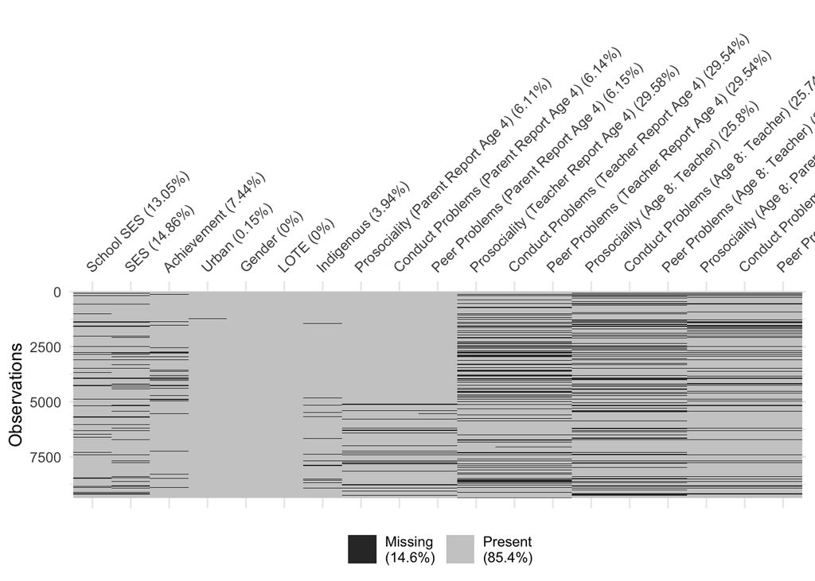

## Missing Data Upset Plot

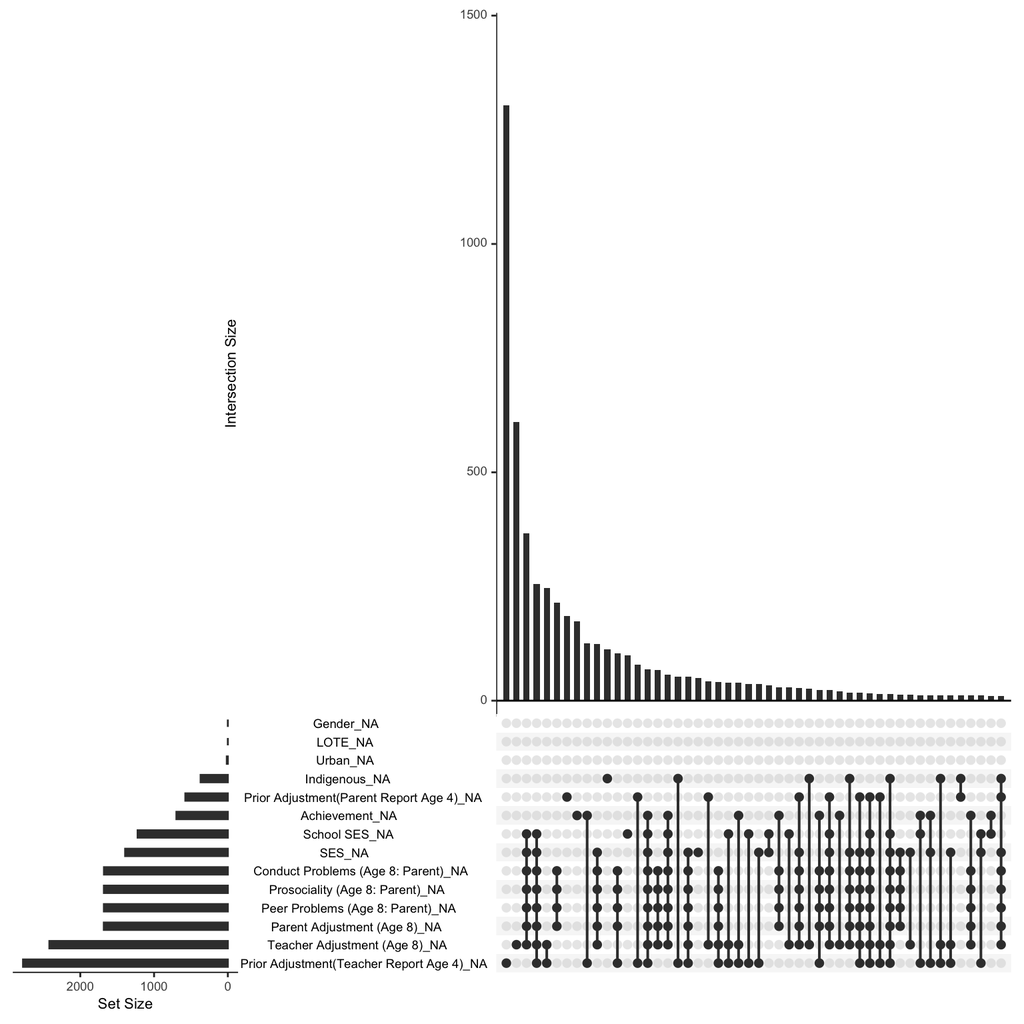

An upset plot aims to show patterns in the data. The *side barchat* on the left shows the number of participants who have missing data for that variable. The *top barchart* shows the number of people with a given pattern of missing data. The *dot plot* shows the missing data pattern. For example a pattern with missing on achievement and ses will have a dot on those two variables linked with a black line. Because people who had missing on one social adjustment variable had missing on all social adjustment types, we have combined missing for age 4 prior, age 8 teacher, and age 8 parent social adjustment respectively.

## Missing Data by Variable

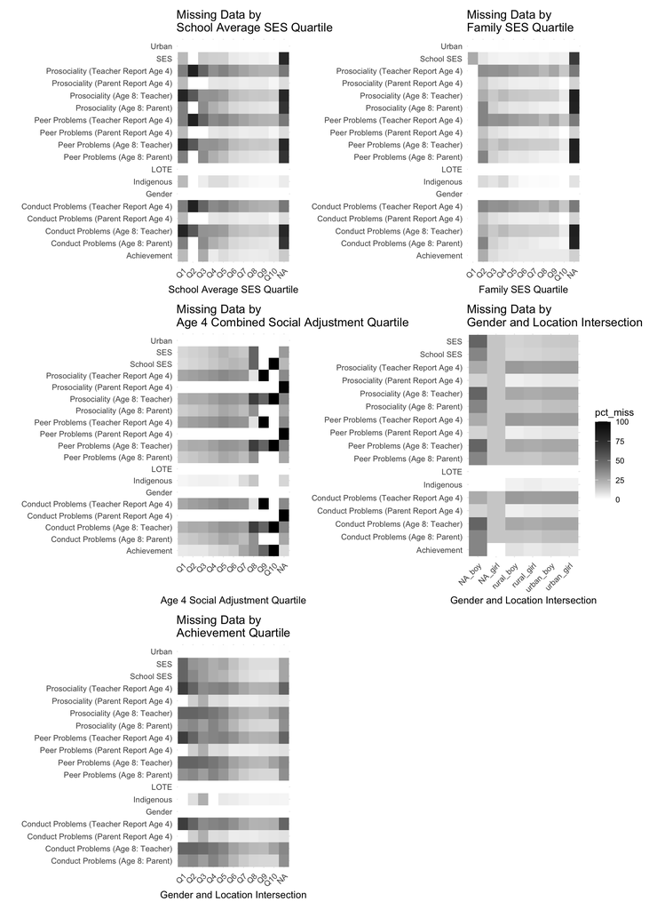

These plots show the amount of missing data per variable across the quatiles (of continuous variables) of factor levels (of categorical variables).